# Guion de Prácticas de la parte de *Introducción a la Estadística* del curso *Introducción a la Ciencia de Datos*

© Juan Carlos Cubero

02 octubre, 2024

Este guion está diseñado para que vaya aplicando los test de hipótesis que se han visto en la parte teórica del curso. Su realización se hará durante las clases presenciales del Máster. El alumno no tiene que entregar nada relativo a esta parte. De hecho, el 95 por ciento de este guion está resuelto.

Se usarán varios conjuntos de datos cuyos enlaces se proporcionan a lo largo del guion conforme se van necesitando. También puede descargarlos todos desde el siguiente enlace:

https://decsai.ugr.es/jccubero/Master/IntrodEstadisticaData.zip

En primer lugar se verá el uso de la herramienta Jamovi que es un entorno gráfico para seleccionar los tests de hipótesis que se quieran ejecutar. Si el alumno termina durante las clases prácticas esta parte, puede pasar a la parte de R en la que se ve cómo ejecutar los mismos tests (y otros más avanzados) desde R.

En lo que sigue, nos vamos a centrar en el caso de una variable dependiente continua (puede ser ordinal en el caso de los tests no paramétricos) y una única variable independiente o factor. En el caso de que tuviésemos en cuenta varios factores, habría que tener en cuenta la interacción entre los distintos niveles o grupos de dichas variables (*multiway Anova*). Si tuviésemos varias variables dependientes tendríamos que recurrir a las técnicas englobadas bajo el término *MANOVA*. Si consideramos también variables continuas como factores, recurriríamos al *ANCOVA*.

Resumen de los tests que se van a ver en este guion (con Jamovi y con R):

- *Tests para muestras independientes*

  Las filas han de ser independientes entre sí. Los grupos han de ser independientes entre sí.
  - *Test para dos muestras*
    - *Paramétrico*. Los residuos han de ser normales. Dependiendo de si las varianzas son similares o no (según nos indique el test de **Levene**) tenemos:
      - *Varianzas similares*: **t-test**
      - *Varianzas distintas*: **Welch**
    - *No paramétrico*: **Mann-Whitney** (es un test sobre las medianas cuando las distribuciones son similares y es un test de dominancia estocástica en otro caso)
  - *Test para k muestras*
    - *Paramétrico*. Los residuos han de ser normales.
      - *Varianzas similares*: **One-way Anova**. Post-hoc: **Tukey HSD**
      - *Varianzas distintas*: **Welch**. Post-hoc: **Games-Howell**
      - En cualquiera de los casos anteriores se puede aplicar un post-hoc genérico como por ejemplo Holm.
    - *No paramétrico*: **Kruskal-Wallis** (es un test sobre las medianas cuando las distribuciones son similares y es un test de dominancia estocástica en otro caso). Post-hoc: **Dwass-Steel-Critchlow-Fligner**, **Dunn**, **Conover**, **Nemenyi**. También se puede aplicar un post-hoc genérico.
- *Tests para muestras dependientes (medidas repetidas)*

  Las filas han de ser independientes entre sí.
  - *Test para dos muestras*
    - *Paramétrico*. Los residuos de las diferencias han de ser normales. Se aplica el **paired t-test**
    - *No paramétrico*: Si la diferencia de las dos variables es una distribución simétrica, se aplicará **Wilcoxon**. En otro caso, el **sign-test**
  - *Test para k muestras*
    - *Paramétrico*. Los residuos han de ser normales. Se aplica el **Anova de medidas repetidas**. Si no se verifica la hipótesis de esfericidad (test de **Mauchly**) se aplica la corrección de **GreenHouse-Geiser**. Post-hoc con **Tukey** o uno genérico.
    - *No paramétrico*: **Friedman** (es un test sobre las medianas cuando las distribuciones son similares y es un test de dominancia estocástica en otro caso). Post-hoc: **Durbin-Conover**, **Nemenyi**, **Eisinga**, etc. También se puede aplicar un post-hoc genérico.

Puede consultar en el siguiente enlace una tabla completa con los distintos tests a aplicar, dependiendo de los datos con los que trabajamos:

http://statkat.com/stattest_overview.php

# 1 Tests de Hipótesis con Jamovi

Puede descargar Jamovi desde el siguiente enlace:

https://www.jamovi.org/

## 1.1 Tests para muestras independientes

### 1.1.1 Prueba para dos muestras independientes (test paramétrico)

- dataset: [Datos de empleados](https://decsai.ugr.es/jccubero/Master/DatosEmpleados.omv)
- test: ¿Puede considerarse que el salario medio de los hombres es igual al de las mujeres?
- Variable dependiente: `salario`
- Variable independiente (o factor): `sexo`

El conjunto de datos de empleados es un dataset ficticio incluido en la distribución de SPSS y almacena información de los trabajadores de una empresa.

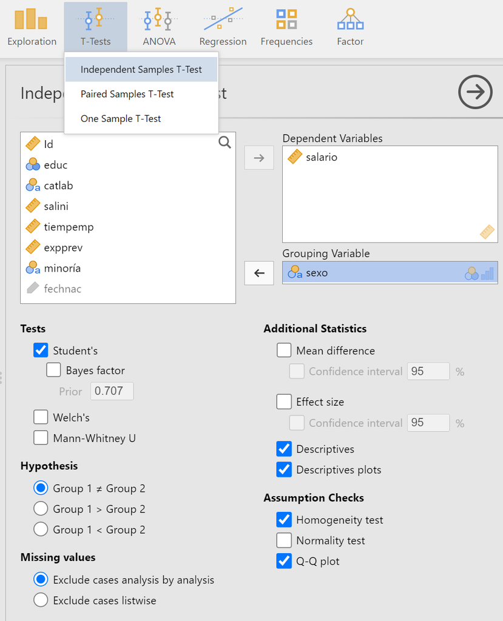

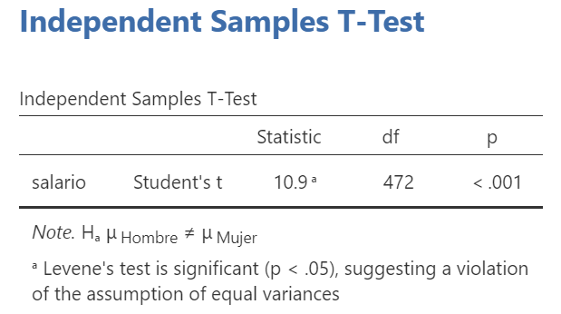

El test es significativo por lo que rechazaríamos la hipótesis nula y aceptaríamos que los hombres no tienen el mismo salario que las mujeres. En el gráfico descriptivo, podemos apreciar la diferencia que hay entre las medias de los dos grupos (la barra sobre el valor de la media representa el intervalo de confianza para dicho valor)

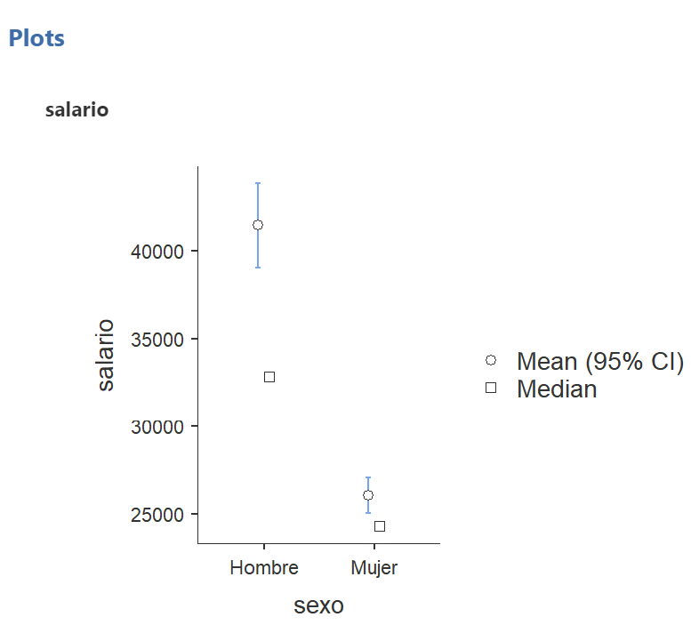

En cualquier caso, tenemos que analizar los requisitos del test:

- **Independencia de las dos muestras**: En el diseño de un experimento, el científico debe asegurar que los sujetos (personas, animales, materiales, etc.) son elegidos y asignados a cada muestra de forma **aleatoria**. Esto es lo que garantiza que los sujetos de cada muestra sean independientes y los resultados del experimento no se vean condicionados por un posible sesgo en la elección de los sujetos o la asignación de un sujeto a una muestra u otra. Por ejemplo, podríamos estar interesados en ver el efecto de un relajante en una población de ratones, para lo cual medimos el número de horas de sueño. Normalmente se usarán dos muestras: una de ellas recibirá el relajante y la otra no (será un grupo de *control*). En primer lugar, los ratones deberían elegirse de forma aleatoria, de forma que no deberían seleccionarse únicamente los machos, o los que tengan una característica determinada. En segundo lugar, también ha de ser aleatoria la asignación de cada ratón al grupo de los que recibirán el relajante o al grupo de control. En definitiva, se ha de asegurar:
  - La independencia entre las filas de un mismo grupo
  - La independencia entre las filas de distintos grupos

  En nuestro caso, no vamos a extraer una muestra de una población de posibles sujetos sino que vamos a trabajar con **todos** los datos que ya han sido obtenidos previamente. En cualquier caso, debemos asegurar que los sujetos que vamos a comparar (las filas o registros del dataset) son independientes. Supongamos por ejemplo los datos de los empleados.
  - ¿Podemos garantizar que la elección de cada sujeto ha sido aleatoria? Debemos suponer que los empleados actuales de la empresa representan una muestra de un conjunto mucho mayor de posibles empleados que, cumpliendo los requisitos, podrían haber optado a un puesto. ¿La incorporación a la empresa de un empleado viene condicionada por la contratación de otro? Si fuese así, no podríamos considerar que las filas son independientes entre sí.
  - ¿Podemos garantizar que la *muestra* constituida por los empleados varones es independiente de la *muestra* de las mujeres? Supongamos que la mayor parte de los empleados de la empresa pertenecen a grupos familiares y que al contratar a una persona, se intenta siempre contratar también a un hermano de otro sexo de la misma familia. En este caso, es muy posible que exista un sesgo determinado por el grupo familiar. Por ejemplo, puede ser que los miembros de una misma familia tengan un nivel de estudios similar y por tanto es muy posible que tengan la misma categoría laboral, salarios similares, etc. Esta *dependencia* introduce un sesgo que puede invalidar el resultado del test ya que podría ser no significativo (no se rechaza que las medias son similares) cuando realmente, si eliminamos los datos de los hermanos sí obtendríamos un test significativo (se rechararía por tanto que las medias son similares).

  En todos los tests de hipótesis que vamos a ver en este apartado de muestras independientes supondremos que se verifican ambas hipótesis de independencia y por tanto, la presencia de una fila no condiciona la presencia de otra fila ni en el mismo grupo ni entre grupos diferentes.

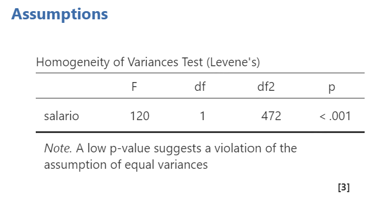

En el caso de varianzas distintas, aplicamos mejor el test de **Welch**, seleccionando la casilla correspondiente:

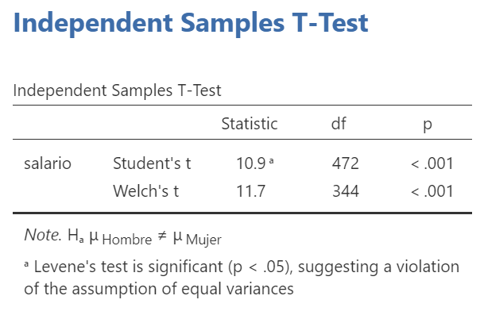

El test resulta significativo. En cualquier caso, el test de Welch también requiere que se cumpla la hipótesis de normalidad:

- **Normalidad** de los residuos. Si seleccionamos las casillas de “Normality test” y “q-q plot” en el apartado “Assumption checks” obtenemos el gráfico que aparece abajo. Podemos apreciar que los residuos **NO** siguen una distribución normal (los puntos deberían estar todos cercanos a la línea de referencia) El correspondiente test de **Shapiro Wilks** también rechaza la hipótesis de normalidad.

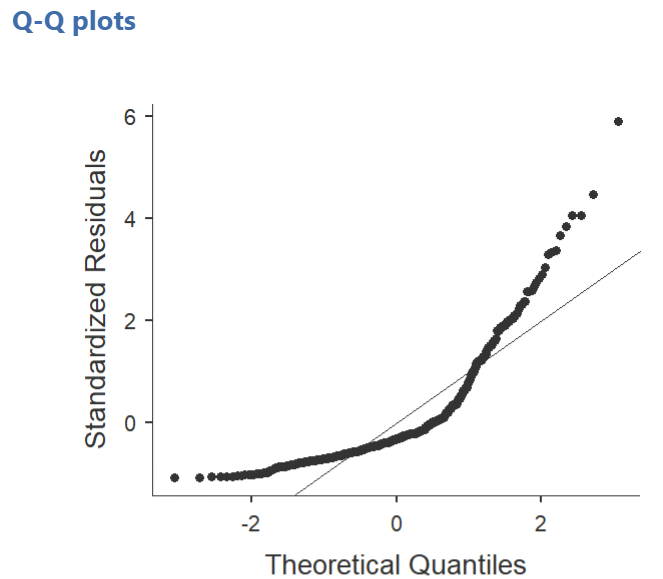

En resumen: Hemos aplicado el test de Welch al tener los grupos varianzas distintas. Éste resulta significativo por lo que podemos concluir que, efectivamente, el salario medio de los hombres es distinto al de las mujeres. Como la media del salario de los hombres es 41442 y el de las mujeres es 26032, podemos concluir que el salario medio de los hombres es mayor estricto que el de las mujeres. Esta afirmación no tiene una garantía estadística completa ya que, aunque los tests paramétricos como la t-Student y el de Welch son bastante robustos a la violación del requisito de la normalidad, es conveniente aplicar un test no paramétrico que, aunque tenga menos potencia, no requiere que se cumpla la hipótesis de normalidad. Esto lo haremos a continuación.

**Nota**: Estamos planteando como hipótesis nula la igualdad de las medias y como alternativa que sean distintas (*test a dos colas*). Es posible plantear tests más específicos en los que la hipótesis nula sea, por ejemplo, que la media de los hombres es mayor y la alternativa sea que la media sea menor o igual (*test a una cola*)

### 1.1.2 Test no paramétrico para comparar dos muestras independientes

- dataset: [Datos de empleados](https://decsai.ugr.es/jccubero/Master/DatosEmpleados.omv)
- test (en el caso de varianzas similares): ¿Puede considerarse que la **mediana** del salario de los hombres es igual al de las mujeres?
- test (en el caso de varianzas distintas): ¿Puede considerarse que el salario de los hombres es *estocásticamente* igual al de las mujeres?
- Variable dependiente: `salario`
- Variable independiente (o factor): `sexo`

En el mismo cuadro de diálogo del apartado paramétrico , seleccionamos la casilla **Mann-Whitney** y nos debe salir el siguiente resultado:

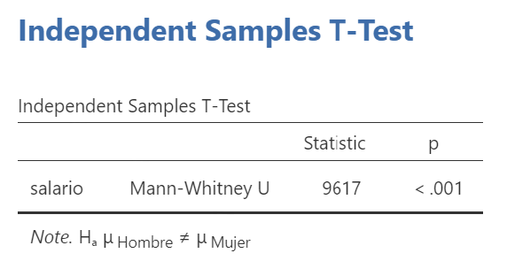

El test de Mann-Whitney resulta significativo. Veamos los requisitos del test:

- Como en todos los tests de este guion, asumimos que las filas son independientes entre sí.
- El test de Mann-Whitney no impone el requisito de que las distribuciones de los grupos sean normales. En cualquier caso, si queremos que sea un test sobre las medianas, sí se necesita que las distribuciones de la variable dependiente en cada uno de los grupos sean similares (el histograma del salario en los hombres debe ser similar al histograma del salario en las mujeres) Pero resulta que ni siquiera las varianzas de los grupos son similares, por lo que no podemos asegurar que se verifica este requisito. Por lo tanto, el test de Mann-Whitney no podemos decir que sea un test sobre las medianas sino un test de *dominancia estocástica*.

En resumen, podemos concluir que el salario de los hombres es *estocásticamente mayor* que el de las mujeres, es decir, que si elegimos al azar un hombre y una mujer, es más probable que el salario mayor corresponda al del hombre. No podemos concluir que las medianas sean distintas.

### 1.1.3 Anova para k muestras independientes (test paramétrico)

#### 1.1.3.1 Test conjunto (omnibus)

- dataset: [Datos de empleados](https://decsai.ugr.es/jccubero/Master/DatosEmpleados.omv)
- test: ¿Puede considerarse que el salario medio es el mismo en cada una de las **tres** categorías laborales (k=3)?
- Variable dependiente: `salario`
- Variable independiente (o factor): `catlab`

Seleccionamos ANOVA/One-Way Anova

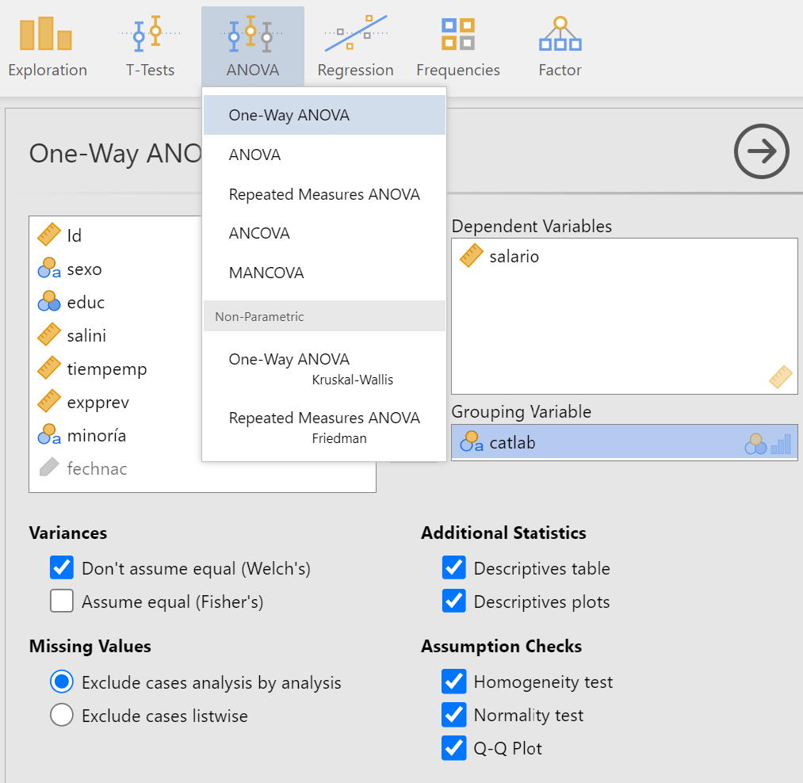

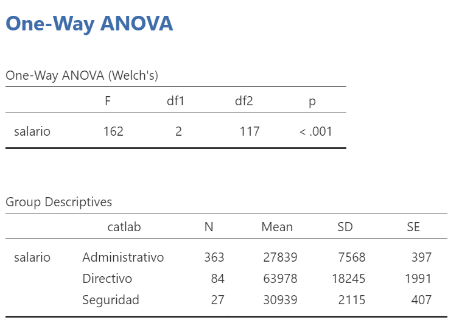

El test resulta significativo, pero debemos comprobar si se verifican los requisitos del test que, al igual que ocurría en el caso de dos muestras independientes, son la independencia de los datos, la homocedasticidad y la normalidad.

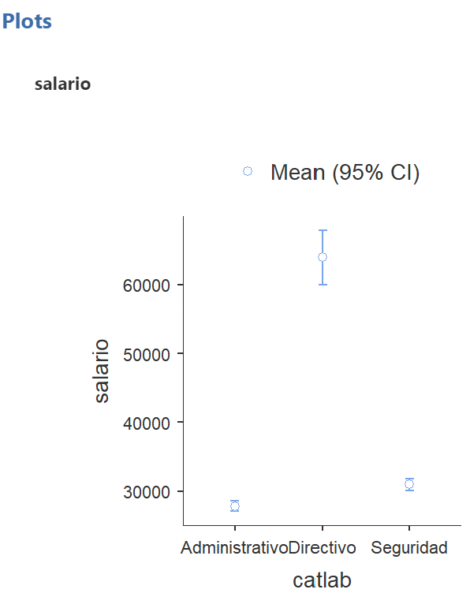

- Normalidad de los residuos. Si analizamos los residuos, vemos que una parte de éstos se alejan mucho de la línea de referencia por lo que no podemos asumir que éstos sigan una distribución normal.

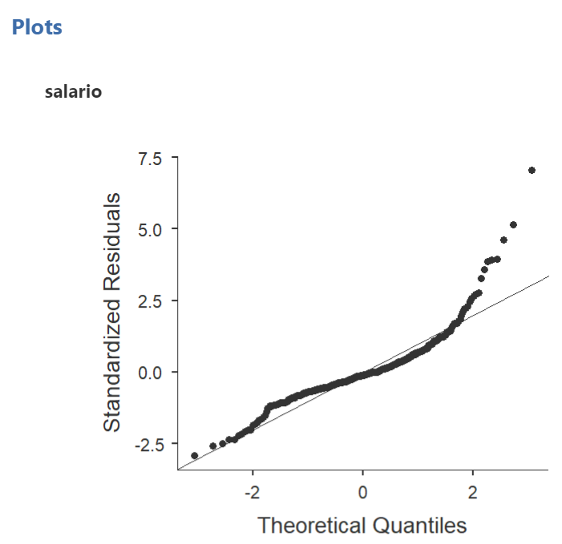

En resumen, al tener varianzas distintas en cada uno de los grupos, hemos aplicado el test Anova de Welch y ha resultado significativo, por lo que podemos concluir que hay al menos un grupo con un salario medio distinto al resto de los grupos. En cualquier caso, aunque tal y como ocurría en el caso de dos muestras independientes el test de Anova es bastante robusto a violaciones de la normalidad de los residuos, este requisito no se cumple por lo que no tenemos una garantía estadística completa y por tanto es preferible ejecutar el mismo estudio pero usando un test no paramétrico (lo haremos posteriormente)

#### 1.1.3.2 Post hoc

Procedemos a realizar las comparaciones múltiples dos a dos entre todos los grupos de la variable independiente o factor (categoría laboral) Si tenemos $k$ grupos, en el post hoc estaremos planteando un total de $k(k-1)/2$ comparaciones, por lo que, tal y como hemos visto en el curso, los métodos tendrán que controlar el error FWER. Los métodos que hemos denominado *específicos* realizan algún tipo de penalización interna en la construcción del propio test y otros (los que hemos denominado *genéricos*) aplican un test normal para el caso de dos muestras a cada una de las $k(k-1)/2$ posibles combinaciones y luego aplican una penalización del nivel de significación (**Bonferroni**, **Sidak**, **Holm**, **Hochberg**, etc.)

Uno de los métodos *específicos* más usados en el caso del Anova paramétrico con varianzas distintas es el test de **Games-Howell**. Si las varianzas no fuesen distintas, seleccionaríamos el método de **Tukey HSD** (aunque el test de Games-Howell también tiene una potencia similar a éste en el caso de varianzas iguales)

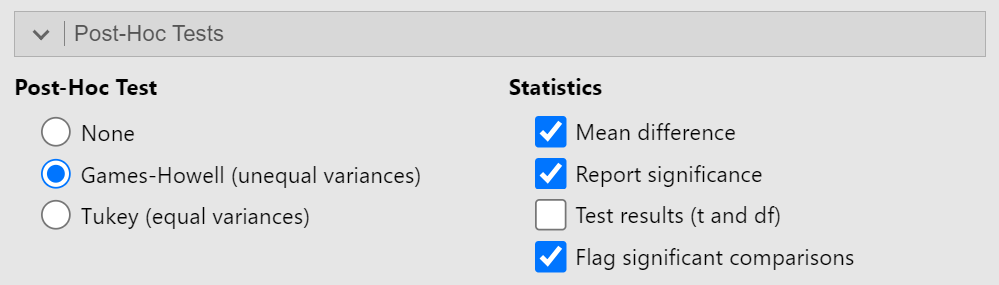

Nos debe salir lo siguiente:

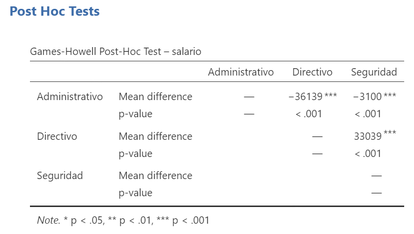

Vemos que las comparaciones de todos los pares de categoría (Administrativo vs Seguridad, Administrativo vs Directivo, Seguridad vs Directivo) han resultado significativas por lo que concluimos que las tres categorías laborales tienen medias distintas.

Para que compruebe la importancia de considerar la varianza, ejecute el mismo post hoc pero usando el método de Tukey. Puede observar que este test no es capaz de rechazar la igualdad entre las medias de Administrativo y Seguridad.

Tal y como hemos comentado anteriormente, para realizar cada una de las $k(k-1)/2$ comparaciones múltiples, también podríamos haber aplicado un *test genérico* sobre cada par de medias y penalizar los niveles de significación con algún método como Holm. Para lanzar este tipo de tests, nos tenemos que ir a otro cuadro de diálogo en Jamovi. Debemos seleccionar ANOVA/ANOVA y en la pestaña Post Hoc Tests seleccionamos catlab. Usamos el método de penalización por pasos de Holm:

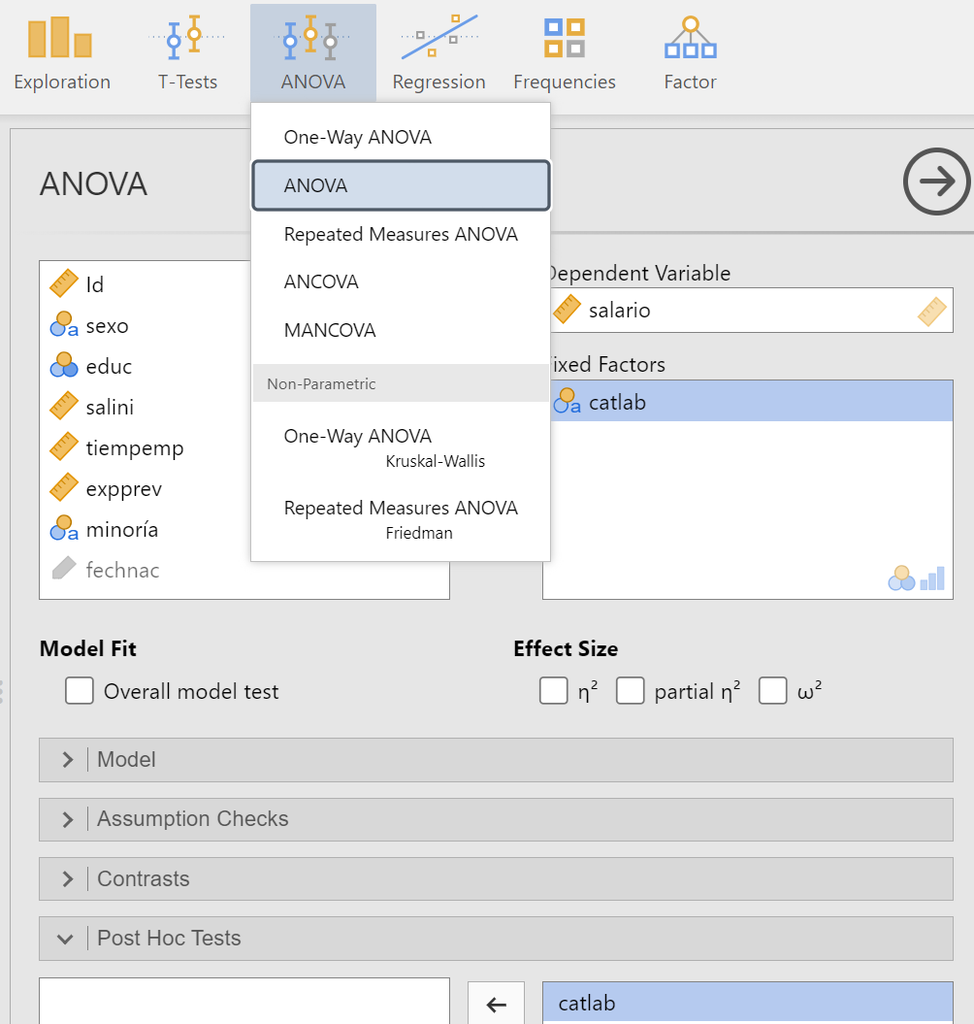

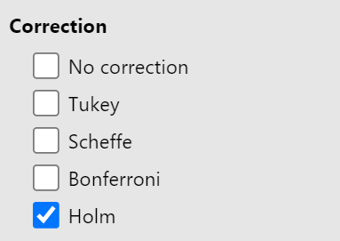

Nos debe salir lo siguiente:

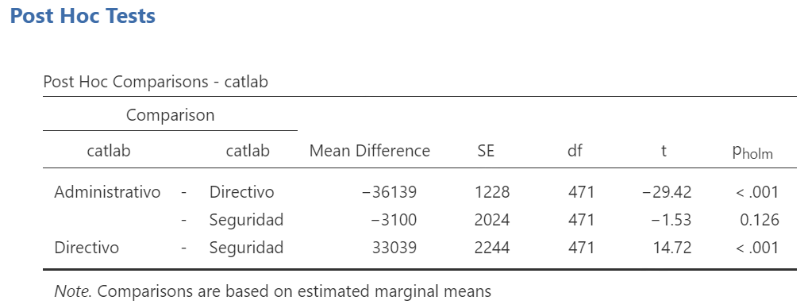

Vemos que el test sí distingue entre directivos y las otras dos categorías pero no es capaz de rechazar la igualdad entre administrativos y seguridad, algo que sí hacía el test de Games-Howell. La razón es que Jamovi lanza el post hoc usando como test genérico para realizar cada comparación el t-test. Pero para estimar la varianza utiliza la denominada *varianza agregada* (*pooled variance*). Esto sólo tiene sentido cuando las varianzas de cada grupo son similares, algo que ya hemos visto que no ocurre. Por lo tanto, en los cómputos del estadístico, los directivos aportan una varianza muy alta que domina sobre el resto de los grupos. En definitiva, en este caso de varianzas distintas no deberíamos aplicar este post hoc y deberíamos aplicar únicamente el test de Games-Howell. Cuando veamos la parte del guion con R, veremos cómo aplicar tests genéricos de forma correcta.

En resumen, si va a usar Jamovi, cuando los datos no cumplan el requisito de homocedasticidad, use únicamente el test de Games-Howell como post-hoc al Anova de Welch

*Nota* El test de Welch sólo está disponible en el cuadro de díalogo ANOVA/One-way Anova pero no lo está bajo el cuadro de diálogo de ANOVA/ANOVA. La razón es que el ANOVA genérico permite utilizar varias variables independientes o factores para analizar cómo interactúan entre ellas (el Anova de una vía -one way Anova- sólo considera un único factor) En estos casos, el test de Welch no es aplicable.

### 1.1.4 Anova para k muestras independientes (test no paramétrico)

#### 1.1.4.1 Test conjunto (omnibus)

- dataset: [Datos de empleados](https://decsai.ugr.es/jccubero/Master/DatosEmpleados.omv)
- test (en el caso de varianzas distintas): ¿Puede considerarse que el salario en cada una de las tres categorías laborales es *estocásticamente* igual al del resto de categorías?
- test (en el caso de varianzas similares): ¿Puede considerarse que la **mediana** del salario es la misma en cada una de las **tres** categorías laborales?

En el Anova paramétrico vimos que no se cumplía el requisito de normalidad de los residuos. Si bien es cierto que el Anova es bastante robusto a desviaciones de la normalidad, si queremos guardarnos las espaldas, podemos lanzar un test no paramétrico que no imponga dicho requisito. El test no paramétrico a ejecutar sería el de **Kruskal-Wallis**.

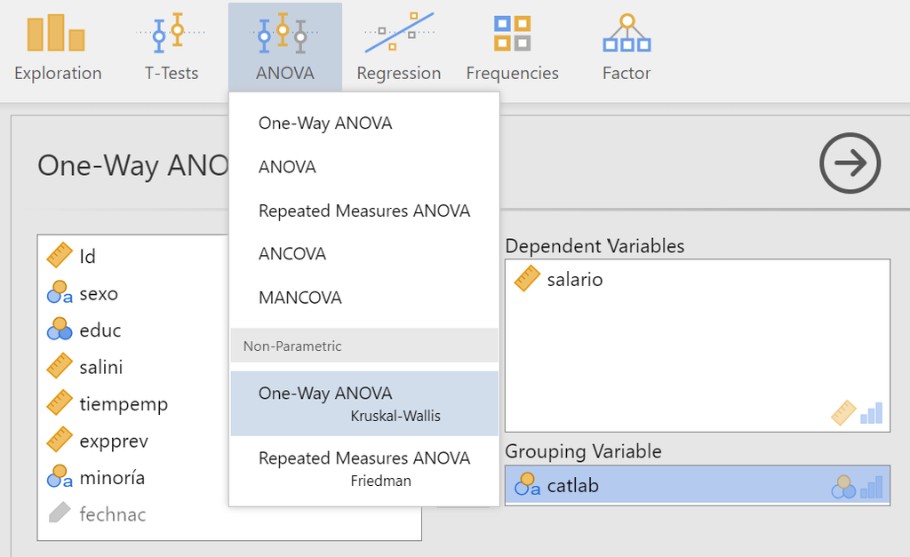

Nos debe salir lo siguiente:

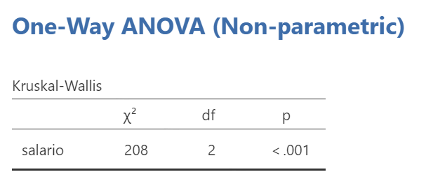

Al igual que en el test no paramétrico de 2 muestras independientes, si las varianzas (en realidad el histograma completo) de cada grupo fuesen similares, el test no paramétrico de Kruskal-Wallis sería un test sobre las medianas por lo que podríamos concluir que hay alguna mediana significativamente mayor (o menor). Como las varianzas son realmente muy distintas en cada grupo, el test *sólo* puede concluir que hay algún grupo que domina estocásticamente sobre otro.

#### 1.1.4.2 Post hoc

Si en el mismo cuadro de diálogo del test de Kruskal-Wallis seleccionamos el post-hoc de DSCF (**Dwass-Steel-Critchlow-Fligner**), obtenemos:

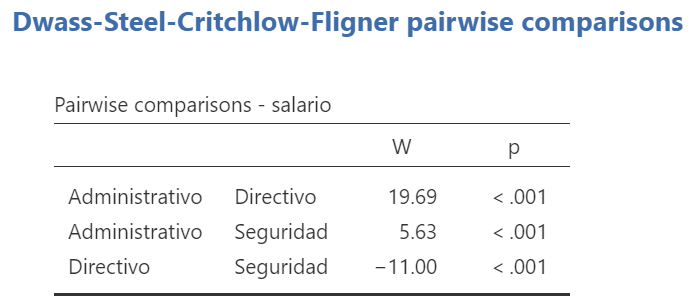

## 1.2 Tests para muestras dependientes o de medidas repetidas

Ahora vamos a trabajar con **muestras dependientes**. El ejemplo típico es cuando a un mismo sujeto se le realizan varias medidas (de ahí el nombre de *medidas repetidas*) Por ejemplo, se le administra un fármaco y se mide alguna variable que nos diga cómo responde al tratamiento. Si realizamos tres mediciones (separadas entre sí un número de días), tendremos tres columnas de datos. Las columnas representan muestras dependientes ya que el valor de un registro en cualquiera de ellas está obviamente condicionado por el valor del mismo registro en las otras columnas. En cualquier caso, debemos seguir exigiendo que la elección de los sujetos haya sido aleatoria, es decir, las filas han de ser independientes.

En resumen, en esta sección vamos a aplicar tests en los que:

- Las filas dentro de un grupo son independientes entre sí
- Las filas de un grupo no son independientes del resto de los grupos.

Al igual que en el caso de muestras independientes, tendremos tests paramétricos que exigen ciertos requisitos y tests no paramétricos que rebajan la exigencia de algunos.

### 1.2.1 Prueba T (t-Student) para dos muestras pareadas (medidas repetidas)

- dataset: [Datos de empleados](https://decsai.ugr.es/jccubero/Master/DatosEmpleados.omv)
- test: ¿Puede considerarse que la diferencia entre las medias del salario actual y el salario inicial es cero?

Este es un ejemplo claro de variables pareadas ya que a cada empleado se le realizan dos *mediciones*, a saber, el salario con el que entró a la empresa y el salario actual.

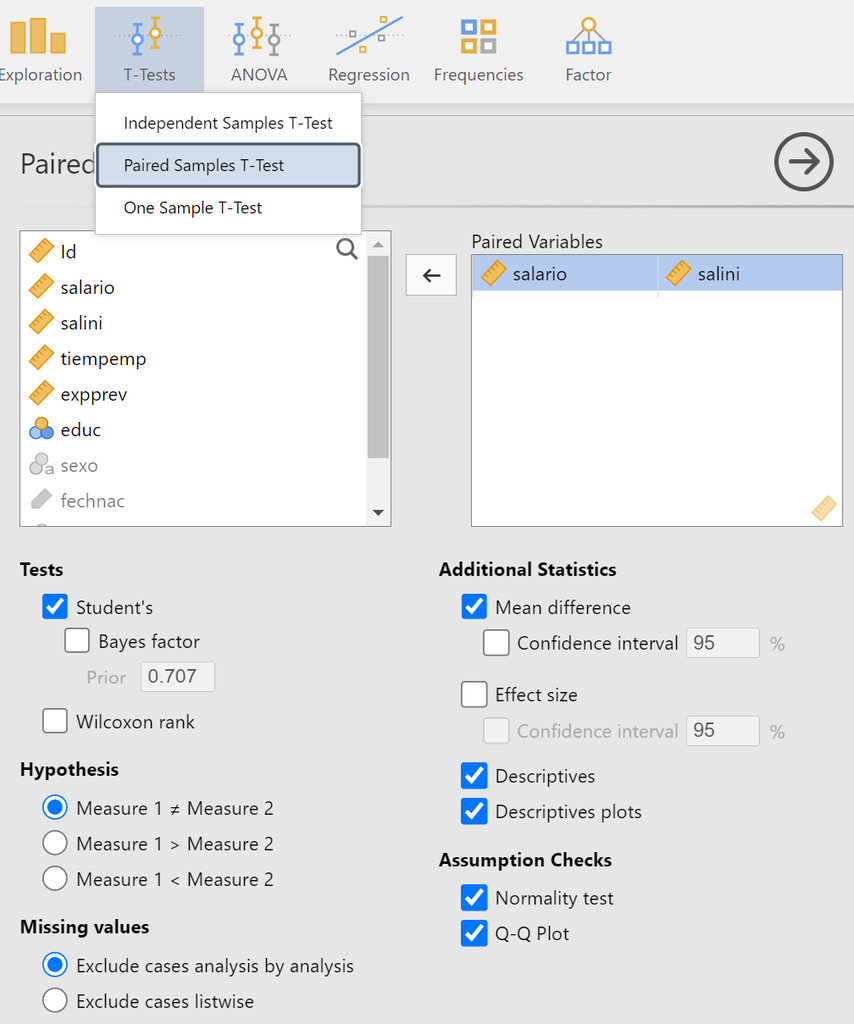

Nos debe salir lo siguiente:

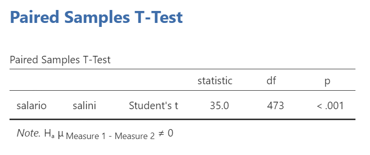

Las condiciones para aplicar este test son las siguientes:

- Las filas deben ser independientes entre sí (realmente, el requisito es que las diferencias obtenidas al restar un dato con su *emparejado* sean independientes) Tal y como hemos comentado anteriormente, supondremos que efectivamente es así.
- Las diferencias entre los valores pareados deben seguir una distribución normal con media cero. En nuestro caso, la variable construida al restar el salario final del inicial, debe seguir una normal centrada en cero.

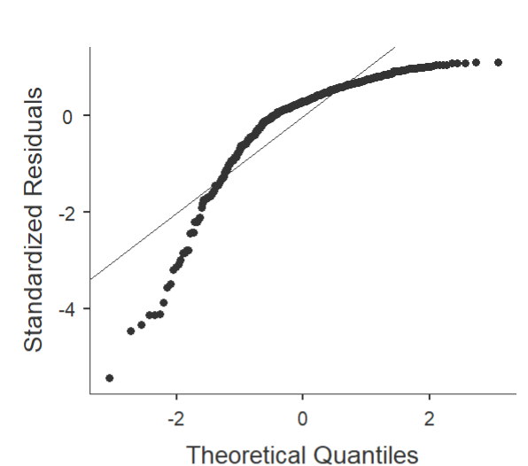

Podemos apreciar que la distribución resultante de las diferencias dista mucho de ser una normal (ya que hay muchos puntos que están distantes de la línea de referencia), por lo que aunque el test es bastante robusto a desviaciones de la normalidad, deberíamos aplicar un test no paramétrico.

### 1.2.2 Test no paramétrico para comparar dos muestras dependientes (medidas repetidas)

- dataset: [Datos de empleados](https://decsai.ugr.es/jccubero/Master/DatosEmpleados.omv)
- test: ¿Puede considerarse que la diferencia entre las **medianas** del salario inicial y el salario final es cero?

Aplicamos el test de **Wilcoxon** marcando la casilla correspondiente en el mismo cuadro de diálogo anterior. Debemos obtener lo siguiente:

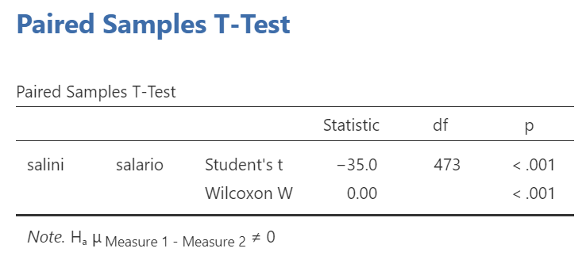

El test resulta significativo por lo que podemos concluir que, efectivamente, las medianas son distintas.

### 1.2.3 Anova para k muestras dependientes (test paramétrico de medidas repetidas)

Al igual que en el caso de k muestras independientes, ahora vamos a analizar la situación que se nos presenta cuando tenemos k (>2) muestras dependientes. Por ejemplo, realizamos tres mediciones de una variable sobre cada uno de los sujetos de un experimento y queremos ver si hay diferencias significativas entre las medias (caso paramétrico) o las medianas (caso no paramétrico)

Como el ejemplo de los datos de los empleados no hay variables de este tipo (no se ha registrado el salario en otro momento que no fuese el inicial y el actual), usamos otro conjunto de datos que se puede descargar del siguiente enlace (proviene originalmente de https://maths.shu.ac.uk/mathshelp/SSupport_Practice.html):

[Colesterol](https://decsai.ugr.es/jccubero/Master/Cholesterol.omv)

Contiene los niveles de colesterol de diferentes individuos. Las mediciones se realizan tres veces, una antes de la aplicación de un tratamiento, otra 4 semanas después y la última 8 semanas después.

#### 1.2.3.1 Test conjunto (omnibus)

- dataset: [Colesterol](https://decsai.ugr.es/jccubero/Master/Cholesterol.omv)
- test: ¿Puede considerarse que las **medias** de las tres mediciones de colesterol son las mismas (k=3)?

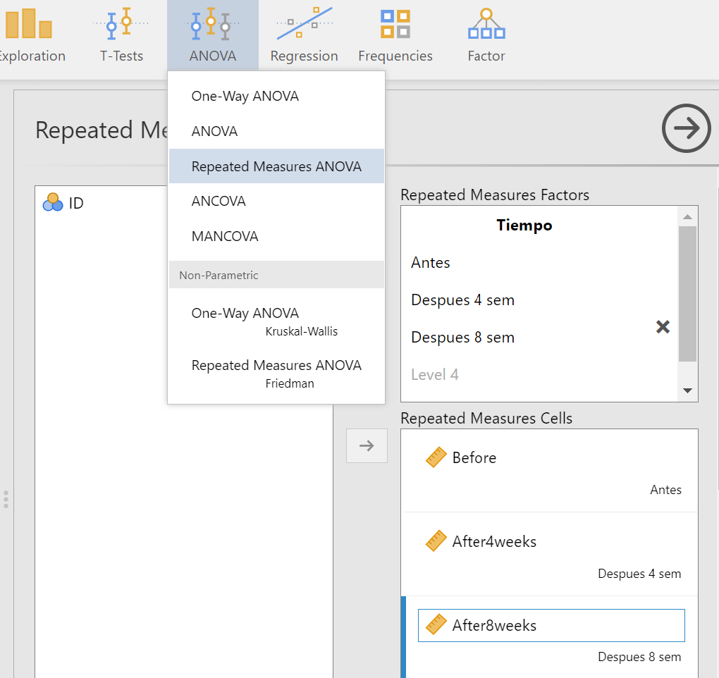

Nos debe salir lo siguiente:

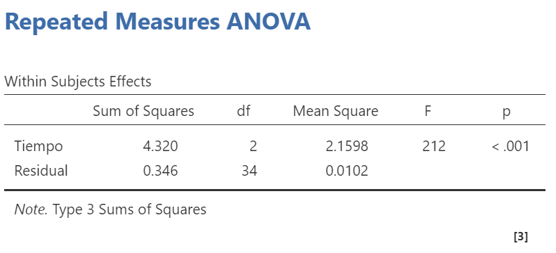

El test es significativo, por lo que rechazaríamos la hipótesis nula de igualdad en las medias. Así pues, parece que el tratamiento cambia el nivel de colesterol. Como siempre, debemos comprobar las condiciones de aplicabilidad del test. En el caso de medidas repetidas son las siguientes:

- Independencia de los datos. Para aplicar el ANOVA de medidas repetidas, al igual que en el caso del Anova de muestras independientes, necesitamos que las filas sean independientes entre sí. Supondremos por tanto que los individuos han sido seleccionados de forma aleatoria. Obviamente, los datos de las columnas no son independientes entre sí (estamos ante un caso de medidas repetidas)
- **Esfericidad**: Las varianzas de las diferencias dos a dos entre todas las columnas de medidas repetidas, han de ser las mismas (el número de comprobaciones obviamente se dispara cuando hay muchas columnas). Para comprobarlo, se aplica el test de **Mauchly**. Desde Jamovi, hay que seleccionarlo en “Assumption checks / Sphericity tests” y podemos ver que da significativo, por lo que rechazamos que las varianzas de las diferencias sean las mismas. Afortunadamente, para solventar el problema, basta con aplicar una penalización en los grados de libertad. En nuestro caso, desde “Assumption checks / Sphericity corrections” seleccionamos **GreenHouse-Geiser** y obtenemos lo siguiente:

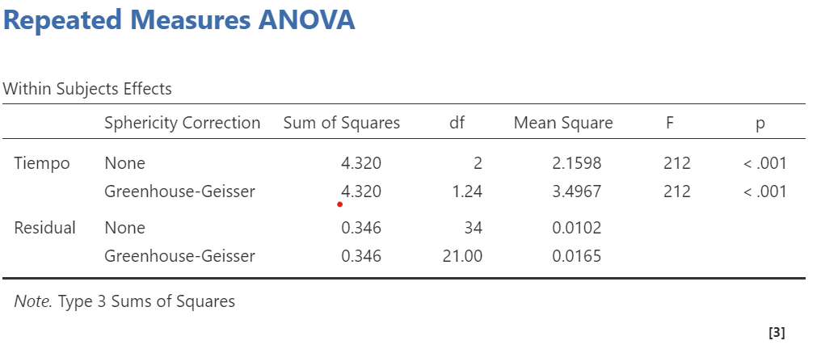

  Como podemos apreciar, aún podemos seguir rechazando la hipótesis nula.
- Normalidad de los residuos. Desde el mismo panel de “Assumption Checks” seleccionamos el gráfico QQ y obtenemos:

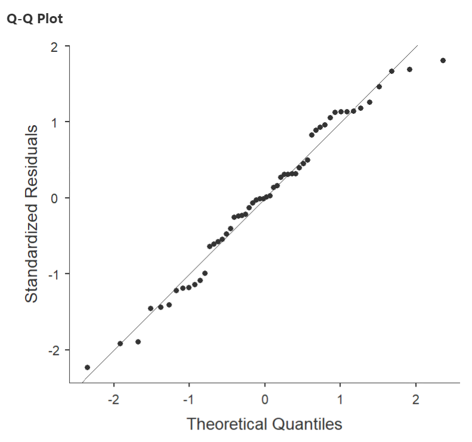

  Vemos que la nube de puntos se distribuye cerca de la línea de referencia, por lo que podemos aceptar que los residuos no se alejan demasiado de una distribución normal.

#### 1.2.3.2 Post hoc

Para realizar las comparaciones múltiples de los tres niveles del factor tiempo, seleccionamos “Post Hoc Tests” y llevamos el factor “Tiempo” al panel de la derecha:

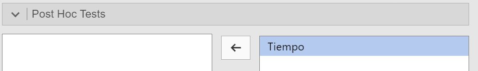

Seleccionamos el método específico de Tukey y el genérico usando Holm como penalización del nivel de significación. Obtenemos lo siguiente:

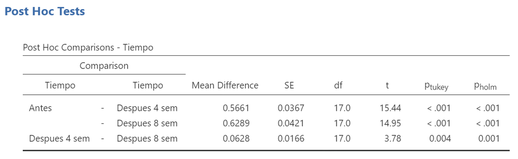

Podemos apreciar que hay diferencias significativas entre todos los niveles del factor “Tiempo”. Observe que si bien era de esperar entre la primera medición y la segunda y entre la primera y la tercera (hay una diferencia media de 0.5661 y 0.6289 respectivamente) no lo era tanto entre la segunda medición y la tercera (hay una diferencia de tan sólo 0.0628) La razón es que la varianza de los valores de dicha diferencia es muy pequeña, lo que permite *afinar* el resultado.

### 1.2.4 Anova para k muestras dependientes (test no paramétrico de medidas repetidas)

Si la hipótesis de normalidad en el anterior test se hubiese violado de una forma muy significativa, tendríamos que aplicar un test no paramétrico como el que vamos a ver en este apartado. Además, en aquellos casos en los que trabajamos con **datos ordinales**, también debemos aplicar un test de este tipo. Vamos a usar otro dataset ficticio proporcionado por SPSS en el que se registran las preferencias (evaluadas de 1 a 10) por distintos individuos sobre cuatro marcas diferentes (son datos ordinales). Si carga los datos del siguiente enlace:

[Preferencias comerciales](https://decsai.ugr.es/jccubero/Master/CommercialRatings.omv)

obtendrá una vista como la siguiente:

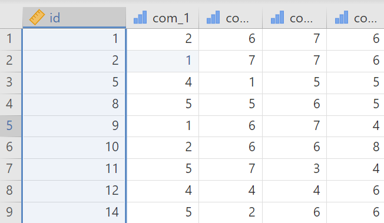

Cada fila corresponde a un individuo y cada columna a una marca. Los valores enteros representan el grado de preferencia de cada individuo a cada marca.

#### 1.2.4.1 Test conjunto (omnibus)

- dataset: [Preferencias comerciales](https://decsai.ugr.es/jccubero/Master/CommercialRatings.omv)
- test (en el caso de que todas las columnas tengan una distribución similar): ¿Puede considerarse que las **medianas** de las preferencias es la misma en las cuatro marcas comerciales (k=4)?
- test (en el caso de que todas las columnas no tengan una distribución similar): ¿Puede considerarse que ninguna marca domina en sus preferencias sobre el resto (k=4)?

Seleccionamos ANOVA/Repeated measures ANOVA Friedman para aplicar el test de **Friedman**.

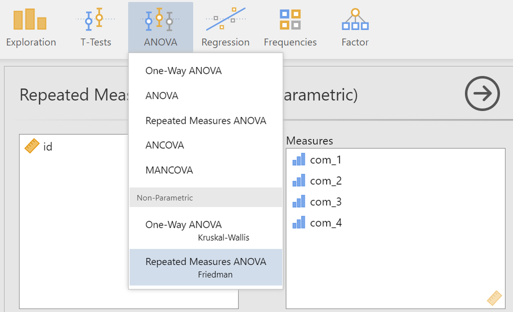

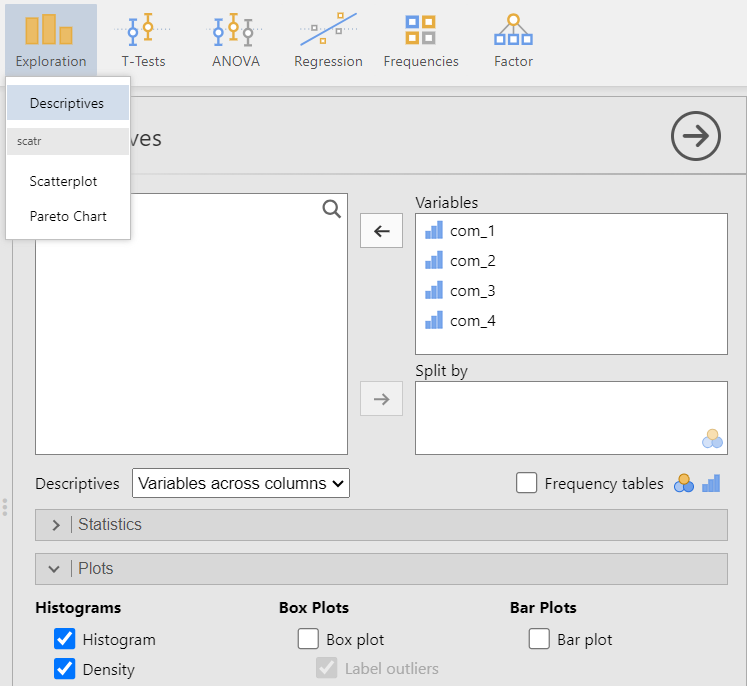

#### 1.2.4.2 Post hoc

Para realizar el post-hoc, Jamovi sólo ofrece por ahora el test de Durbin: “Pairwise comparisons (Durbin-Conover)” Puede ejecutarlo y apreciar que las medianas que pueden considerarse distintas son “com_1”, “com_2” pero no se puede distinguir entre las dos últimas. Así pues obtendríamos {“com_1”, “com_2”, {“com_3”, “com4”}}

En cualquier caso, Jamovi llama al post hoc de Durbin sin aplicar ninguna penalización (debería aplicar una penalización tipo Holm) y ésto sólo sería correcto si el test omnibus de Durbin (un test alternativo al de Friedman) fuese significativo (consulte la ayuda del paquete `PMCMRPlus`). Es de esperar que, en futuras versiones, Jamovi afine este apartado. En la parte de R veremos cómo realizar el análisis correcto.